# GGPlot Customization

Meghan R. Klasic, PhD Student, UC Davis Center for Environmental Policy and Behavior

10/28/2018

This script runs through some customization ideas for ggplot using a simple dummy dataset.

### Packages to Load

```r
library(ggplot2)
library(RColorBrewer)
library(reshape)
library(dplyr)
```

## Reading in the Dummy Dataset

```r
survey <- read.csv("/Users/meghanklasic/RFem/survey.csv")
```

[output not shown]

## Setting up a Customized Theme

Set up your theme at the beginning of your script- then if you are making a bunch of charts/figures for a single manuscript, you can use one word “My Theme” to apply the same theme throughout - saves a ton of time in this case, I took a base theme (theme_bw) and placed it into a function– then using the “%+replace%” you can adjust aspects of the theme. The ggplot2 base themes are here: https://ggplot2.tidyverse.org/reference/ggtheme.html

```r
MyTheme <- function () {
  theme_bw(base_size=12, base_family="Avenir") %+replace%
    theme(
      panel.background  = element_blank(),
      plot.background = element_rect(fill="gray96", colour=NA),
      legend.background = element_rect(fill="transparent", colour=NA),
      legend.key = element_rect(fill="transparent", colour=NA),
      plot.title = element_text(color="black",face="plain",size=16,hjust=0),
      axis.title = element_text(color="#666666", face = "plain", size = 12),
      plot.subtitle = element_text(color= "#666666", size = 12, hjust = 0)
    )
}
```

## Setting up Colors

When making a ggplot, you can just add a code line –> + colScale + brewer.pal colors sets can be viewed here: http://www.datavis.ca/sasmac/brewerpal.html

```r
#this 'saves' 7 color values from Color Brewer Set 3 to the object, Thematic Colors
ThematicColors <- brewer.pal(7, "Set3")
#Assigns factor levels to the 'Org' column and aligns them to the color names selected
names(ThematicColors) <- levels(survey$Org)
#Creates object that holds the color/Org combinations
colScale <- scale_fill_manual(name = "Org", values = ThematicColors)
```

## Setting up Data

Summarizing the total number publications published by Org

```r
survey1 <-survey%>%
  group_by(Org)%>%
  summarise(Sum_grp = sum(Pub_Papers))
```

## Putting it all Together

- x-axis pulls the values from the ‘Org’ column and orders them based on descending number of publications
- y-axis is the total number of publications (created with grouping code)
- fill -> fills the bars in the chart based on the ‘Org’ categories and the color theme set up
- legend.position = none -> removes the legend from the chart
- scale_y_continuous -> sets the min and max values for the y axis
- colScale -> sets up the coloration according to the code
- geom_text -> vjust is the vertical adjustment of the data labels

```r
Chart.plot <- ggplot(survey1, aes(reorder(Org, -Sum_grp), Sum_grp, width = 0.8, fill=Org))+
  geom_bar(position = position_dodge(width = 0.8), color="black", size=0.2, stat = "identity", width = 0.9)+
  MyTheme()+
  labs(title = "Number of Papers that Orgs Publish", subtitle = "This is a subtitle (n = 10)")+
  ylab("Publications")+
  xlab("Orgs")+
  theme(legend.position = "none")+
  scale_y_continuous(limits = c(0,100))+
  colScale+
  geom_text(aes(label = survey1$Sum_grp, vjust = -0.5));Chart.plot
```

## The Resulting Plot

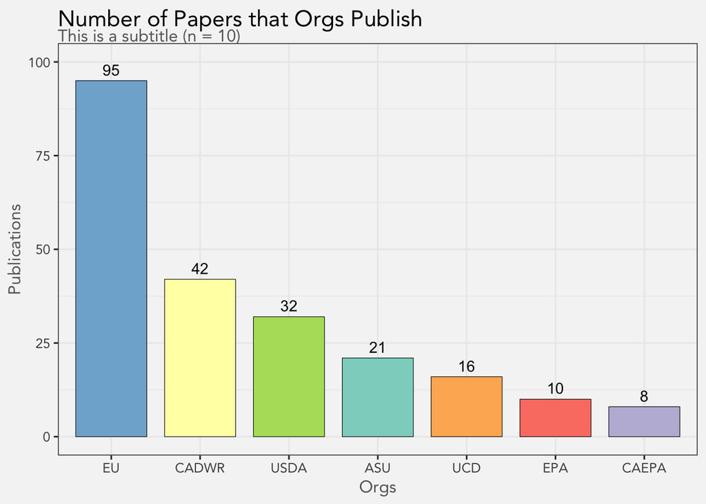

## Saving the Plot

The below code takes the existing plot and saves it with a specified title and width/height.

```r
ggsave("Papers_Published_by_Organization.jpeg", width = 11, height = 8.6)
```